# Test a Perceptual Phenomenon_ext

**This is part of Abdulrahman Alkhamees project work for [Data Analysis Nanodegree](https://sa.udacity.com/nanodegree)**

### Analyzing the Stroop Effect

#### Background information

In a Stroop task, participants are presented with a list of words, with each word displayed in a color of ink. The participant’s task is to say out loud the color of the ink in which the word is printed. The task has two conditions: a congruent words condition, and an incongruent words condition. In the congruent words condition, the words being displayed are color words whose names match the colors in which they are printed: for example RED, BLUE. In the incongruent words condition, the words displayed are color words whose names do not match the colors in which they are printed: for example PURPLE, ORANGE. In each case, we measure the time it takes to name the ink colors in equally-sized lists. Each participant will go through and record a time from each condition.

#### Questions for investigation

As a general note, be sure to keep a record of any resources that you use or refer to in the creation of your project. You will need to report your sources as part of the project submission.

1. What is our independent variable? What is our dependent variable?
2. What is an appropriate set of hypotheses for this task? What kind of statistical test do you expect to perform? Justify your choices.

Now it’s your chance to try out the Stroop task for yourself. Go to this link, which has a Java-based applet for performing the Stroop task. Record the times that you received on the task (you do not need to submit your times to the site.) Now, download this dataset which contains results from a number of participants in the task. Each row of the dataset contains the performance for one participant, with the first number their results on the congruent task and the second number their performance on the incongruent task.

1. Report some descriptive statistics regarding this dataset. Include at least one measure of central tendency and at least one measure of variability.
2. Provide one or two visualizations that show the distribution of the sample data. Write one or two sentences noting what you observe about the plot or plots.
3. Now, perform the statistical test and report your results. What is your confidence level and your critical statistic value? Do you reject the null hypothesis or fail to reject it? Come to a conclusion in terms of the experiment task. Did the results match up with your expectations?

Perform the analysis in the space below. Remember to follow [the instructions](https://docs.google.com/document/d/1-OkpZLjG_kX9J6LIQ5IltsqMzVWjh36QpnP2RYpVdPU/pub?embedded=True) and review the [project rubric](https://review.udacity.com/#!/rubrics/71/view) before submitting. Once you've completed the analysis and write up, download this file as a PDF or HTML file and submit in the next section.

**(1) What is our independent variable? What is our dependent variable?**

- **Dependent variable:** is Stroop Effect result time.
- **Independent variables** are tasks that are either congruent or an incongruent . We are testing whether these variables cause an effect on thedependent variable

**(2) What is an appropriate set of hypotheses for this task? What kind of statistical test do you expect to perform? Justify your choices.**

The statistical test here is to test whether the congruent task result time is equal to incongruent task result time. Therefore, I am establishing the following set of hypotheses:

$$H_0: \mu_{cong} - \mu_{incong} = 0$$$$H_1: \mu_{cong} - \mu_{incong} \neq 0$$

**$\mu_{cong}$ and $\mu_{incong}$ are the population mean values for congruent task and incongruent task, respectively.**

Moreover, we can state the hypothesis as:

- H0: There is **no difference** in population means between the response times under incongruent and congruent scenarios
- H1: There is **a difference** in population means between the response times under incongruent and congruent scenarios

I will be using confidence intervals with a bootstrapping method. For small sample sizes (n=24), using a traditional methods likely involves assumptions that are not true for the interval and could give misleading results simply due to not accurately representing our entire population.

**(3) Report some descriptive statistics regarding this dataset. Include at least one measure of central tendency and at least one measure of variability. The name of the data file is 'stroopdata.csv'.**

```python
#Here we are importing the needed lib.
import pandas as pd
import matplotlib.pyplot as plt
%matplotlib inline
import numpy as np
```

```python
df = pd.read_csv('stroopdata.csv')
```

```python
df.head()
```

|  | Congruent | Incongruent |
| --- | --- | --- |
| 0 | 12.079 | 19.278 |
| 1 | 16.791 | 18.741 |
| 2 | 9.564 | 21.214 |
| 3 | 8.630 | 15.687 |
| 4 | 14.669 | 22.803 |

```python
df.describe()
```

|  | Congruent | Incongruent |
| --- | --- | --- |
| count | 24.000000 | 24.000000 |
| mean | 14.051125 | 22.015917 |
| std | 3.559358 | 4.797057 |
| min | 8.630000 | 15.687000 |
| 25% | 11.895250 | 18.716750 |
| 50% | 14.356500 | 21.017500 |
| 75% | 16.200750 | 24.051500 |
| max | 22.328000 | 35.255000 |

#### Measure of central tendency for Congruent and Incongruent result time

```python
df.Congruent.mean()
```

```
14.051125000000004
```

```python
df.Incongruent.mean()
```

```
22.01591666666667
```

As shown above, on average, the incongruent task takes more time than congruent task.

```python
df.Congruent.std()
```

```
3.559357957645195
```

```python
df.Incongruent.std()
```

```
4.797057122469138
```

**(4) Provide one or two visualizations that show the distribution of the sample data. Write one or two sentences noting what you observe about the plot or plots.**

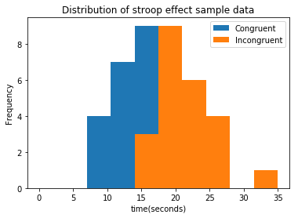

```python
df.plot(kind='hist');
plt.title("Distribution of stroop effect sample data")
plt.xlabel('time(seconds)');
```

We are looking to a normal distribution (bell-curve) for the Stroop effect sample data. We can see that we have an outlier data that we should either deal with or demonstrate the effect of it.

**(5) Now, perform the statistical test and report the results. What is the confidence level and your critical statistic value? Do you reject the null hypothesis or fail to reject it? Come to a conclusion in terms of the experiment task. Did the results match up with your expectations?**

We are going to perform our statistical test by using a bootstrapping method with confidence intervals. The reason for choosing this approach is to eliminate the confusion of p-value.

```python
# Here we take sample, because in real world we don't always have access to the full dataset
sample_df = df.sample(10)
bootsample = sample_df.sample(10, replace=True)
```

```python
# Here we are sampling 10000 time and take the difference in mean each time
diff = []
for _ in range(10000):
    bootsample = sample_df.sample(10, replace=True)
    mean_congruent = bootsample.Congruent.mean()
    mean_incongruent = bootsample.Incongruent.mean()
    diff.append(mean_incongruent - mean_congruent)
```

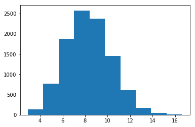

```python
# plotting the difference in mean
plt.hist(diff);
```

```python
np.percentile(diff, 2.5), np.percentile(diff, 97.5)
```

[output not shown]

#### Conclusion

The results suggests that have evidence to reject the null hypothesis. Therefore, **we reject the null in favor of alternative** that suggests that there's is a result time difference between the incongruent & congruent tasks.